# Sars vs. COVID-19

The final plot used stat=summary to find the mean of new COVID cases by week number. Week one had the lowest average new cases, with week five coming in at second lowest. The highest average new case count came from week eight, with close to 6,000 new cases.

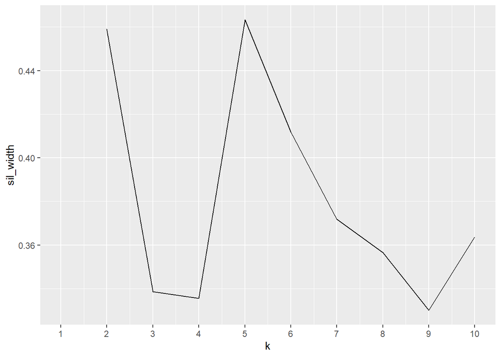

```r
library(cluster)
Clustered <- FULL_New %>% dplyr::select(-Week.Number)
Clustered1 <- Clustered %>% na.omit %>% scale %>% as.data.frame()
sil_width <- vector()
for (i in 2:10) {
    kms <- kmeans(Clustered1, centers = i)
    sil <- silhouette(kms$cluster, dist(Clustered1))
    sil_width[i] <- mean(sil[, 3])
}
ggplot() + geom_line(aes(x = 1:10, y = sil_width)) + scale_x_continuous(name = "k",
    breaks = 1:10)
```

```r
pam1 <- Clustered1 %>% pam(k = 2)
final <- Clustered1 %>% mutate(cluster = as.factor(pam1$clustering))
confmat <- final %>% count(cluster) %>% arrange(desc(n)) %>%
    pivot_wider(names_from = "cluster", values_from = "n", values_fill = list(n = 0))
confmat
```

```
## # A tibble: 1 x 2
##     `1`   `2`
##   <int> <int>
## 1    27    25
```

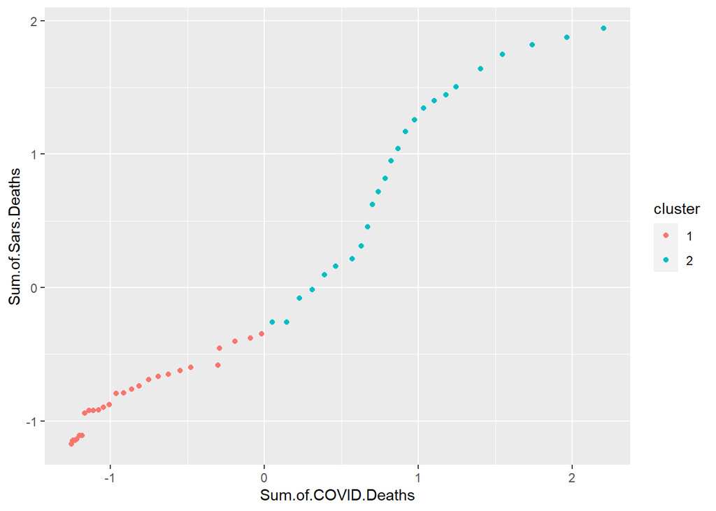

```r
ggplot(final, aes(x = Sum.of.COVID.Deaths, y = Sum.of.Sars.Deaths,
    color = cluster)) + geom_point()
```

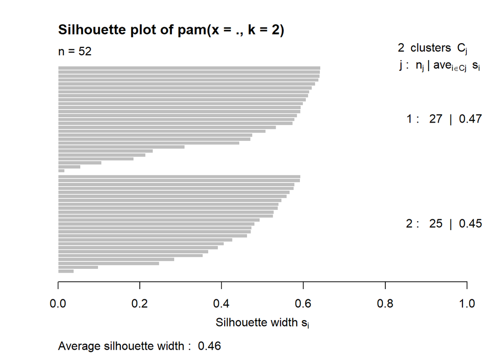

```r
plot(pam1, which = 2)
```

According to the ggplot, the highest average silhouette width came from five clusters (.463), but the second highest was very close and suggested two (.459). Given it is better to choose fewer clusters to achieve parsimony, I decided to have two. The quantity of clusters recommended was based on all numeric variables in the dataset, but only the sums of COVID deaths and Sars deaths were visualized. As seen on the ggplot, there were no real “clusters” or clear separation, but more evenly spaced out points throughout the graph. Given the silhouette width used to derive the clusters was not very high, the cluster solution achieved did not elicit much information.